# TP1 Étude de la taille du cerveau des chauves-souris

Antoine Bichat - Laure Sansonnet

# Chargement des packages

```r
library(tidyverse)
library(FactoMineR)
library(factoextra)
theme_set(theme_minimal())
```

# Présentation des données

#### 1

Le jeu de données possède trois lignes de commentaires, que ses colonnes sont nommées et qu’elles sont séparées par un point-virgule.

```r
df_bats <- read.table("bats.csv", header = TRUE, sep = ";", skip = 3)
```

#### 2

```r
str(df_bats)
```

```
## 'data.frame':    63 obs. of  8 variables:
##  $ Species: Factor w/ 63 levels " Anoura  geofroyi ",..: 52 20 19 12 16 17 47 29 55 41 ...
##  $ Diet   : int  1 1 1 1 1 1 1 1 1 1 ...
##  $ Clade  : Factor w/ 4 levels "I","II","III",..: 1 1 1 1 1 1 1 1 1 1 ...
##  $ BOW    : num  136.3 120 58.7 48.3 184 ...
##  $ BRW    : num  2070 2210 1310 1184 3028 ...
##  $ AUD    : num  9.88 10.44 5.48 4.77 7.09 ...
##  $ MOB    : num  105.8 107.8 67 65.3 213.4 ...
##  $ HIP    : num  126 159.8 97.7 95.4 233.3 ...
```

On remarque que la variable `Diet` est numérique, on va la transformer en facteur.

```r
df_bats <- mutate(df_bats, Diet = factor(Diet))
str(df_bats)
```

```
## 'data.frame':    63 obs. of  8 variables:
##  $ Species: Factor w/ 63 levels " Anoura  geofroyi ",..: 52 20 19 12 16 17 47 29 55 41 ...
##  $ Diet   : Factor w/ 4 levels "1","2","3","4": 1 1 1 1 1 1 1 1 1 1 ...
##  $ Clade  : Factor w/ 4 levels "I","II","III",..: 1 1 1 1 1 1 1 1 1 1 ...
##  $ BOW    : num  136.3 120 58.7 48.3 184 ...
##  $ BRW    : num  2070 2210 1310 1184 3028 ...
##  $ AUD    : num  9.88 10.44 5.48 4.77 7.09 ...
##  $ MOB    : num  105.8 107.8 67 65.3 213.4 ...
##  $ HIP    : num  126 159.8 97.7 95.4 233.3 ...
```

#### 3

La fonction `count()` permet de compter le nombre d’individus par classe.

```r
count(df_bats, Diet)
```

```
## # A tibble: 4 x 2
##   Diet      n
##   <fct> <int>
## 1 1        29
## 2 2         5
## 3 3        27
## 4 4         2
```

```r
count(df_bats, Clade)
```

```
## # A tibble: 4 x 2
##   Clade     n
##   <fct> <int>
## 1 I        21
## 2 II       23
## 3 III       1
## 4 IV       18
```

```r
count(df_bats, Diet, Clade, .drop = FALSE) # .drop = FALSE permet de garder les croisements d'effectif nul
```

```
## # A tibble: 16 x 3
##    Diet  Clade     n
##    <fct> <fct> <int>
##  1 1     I        10
##  2 1     II       19
##  3 1     III       0
##  4 1     IV        0
##  5 2     I         4
##  6 2     II        1
##  7 2     III       0
##  8 2     IV        0
##  9 3     I         7
## 10 3     II        1
## 11 3     III       1
## 12 3     IV       18
## 13 4     I         0
## 14 4     II        2
## 15 4     III       0
## 16 4     IV        0
```

`table()` a un format de sortie plus lisible pour un humain … mais pas pour un ordinateur.

```r
table(df_bats$Diet, df_bats$Clade)
```

```
##
##      I II III IV
##   1 10 19   0  0
##   2  4  1   0  0
##   3  7  1   1 18
##   4  0  2   0  0
```

# Analyse univariée des données

#### 4

```r
summary(df_bats)
```

```
##                        Species   Diet   Clade         BOW
##   Anoura  geofroyi         : 1   1:29   I  :21   Min.   :   2.56
##   Artibeus  lituratus      : 1   2: 5   II :23   1st Qu.:   9.44
##   Aselliscus  stoiczkanus  : 1   3:27   III: 1   Median :  20.20
##   Brachyphylla  cavernarum : 1   4: 2   IV :18   Mean   :  54.29
##   Cardioderma  cor         : 1                   3rd Qu.:  41.25
##   Carollia  perspicillata  : 1                   Max.   :1014.00
##  (Other)                   :57
##       BRW              AUD              MOB               HIP
##  Min.   :  87.0   Min.   : 1.840   Min.   :  0.660   Min.   :  4.80
##  1st Qu.: 273.1   1st Qu.: 4.190   1st Qu.:  5.225   1st Qu.: 18.40
##  Median : 586.0   Median : 5.520   Median : 13.850   Median : 30.60
##  Mean   : 893.4   Mean   : 7.404   Mean   : 31.930   Mean   : 50.80
##  3rd Qu.: 912.0   3rd Qu.:10.040   3rd Qu.: 32.200   3rd Qu.: 53.02
##  Max.   :9121.0   Max.   :27.600   Max.   :243.540   Max.   :331.29
##
```

`geom_bar()` permet de dessiner des diagrammes en bâton.

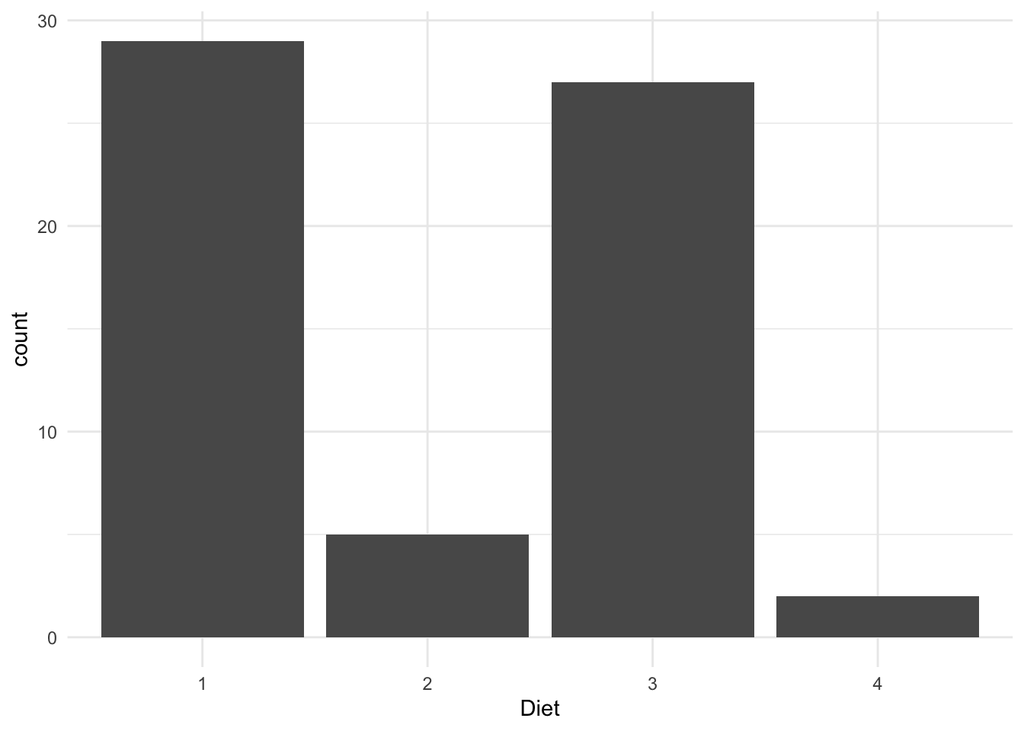

```r
ggplot(df_bats) +
  aes(x = Diet) +
  geom_bar()
```

Mettre une variable sur le remplissage (argument `fill`) adapte automatique le compte par groupe.

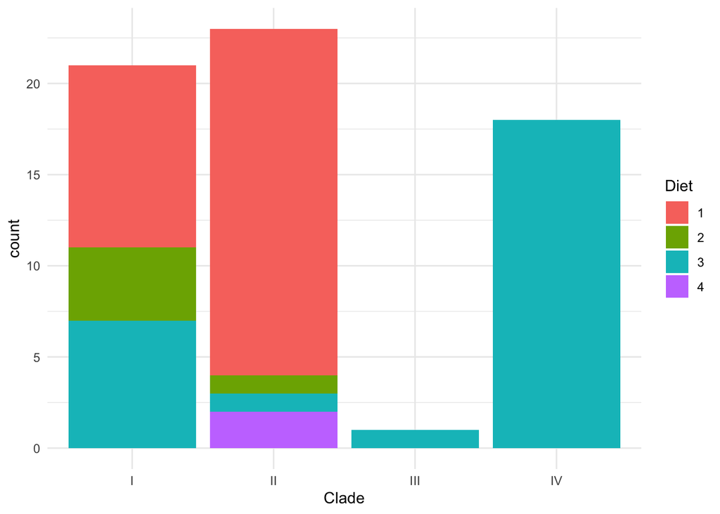

```r
ggplot(df_bats) +
  aes(x = Clade, fill = Diet) +
  geom_bar(position = "stack") # on peut utiliser "dodge" et "fill"
```

Quelques histogrammes et densités avec des options.

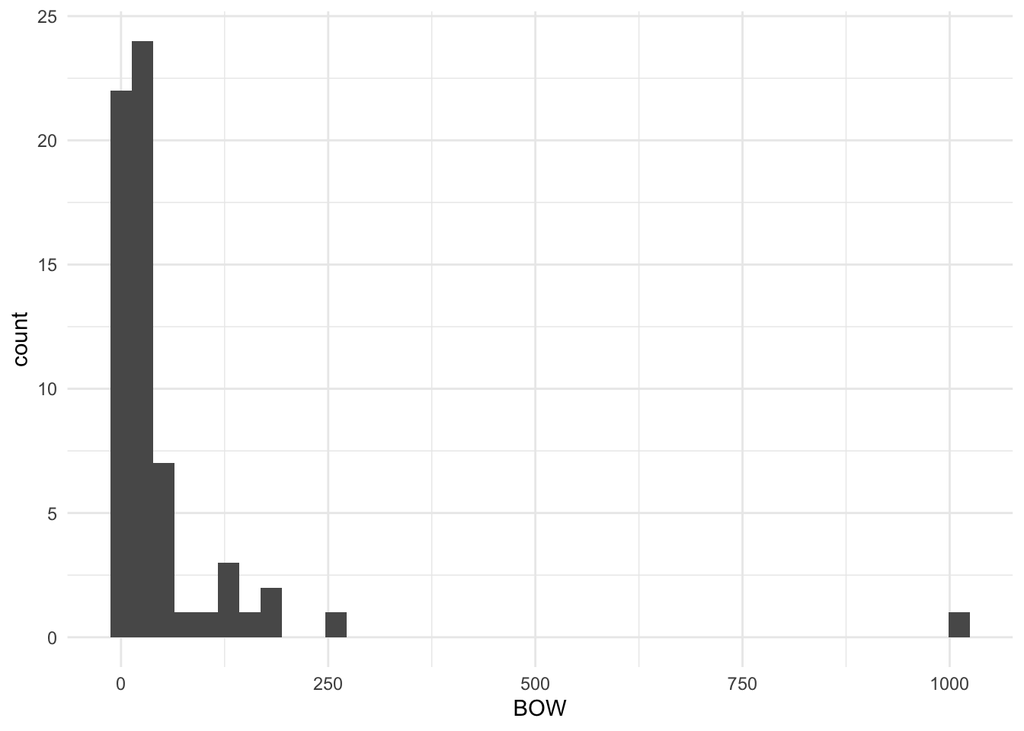

```r
ggplot(df_bats) +
  aes(x = BOW) +
  geom_histogram(bins = 40)
```

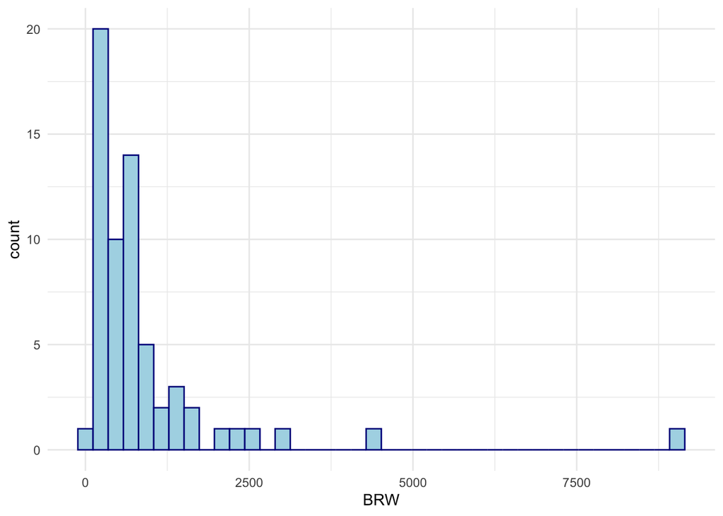

```r
ggplot(df_bats) +
  aes(x = BRW) +
  geom_histogram(bins = 40, fill = "lightblue", color = "darkblue")
```

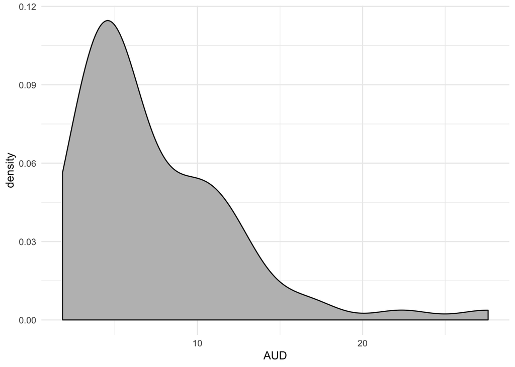

```r
ggplot(df_bats) +
  aes(x = AUD) +
  geom_density(fill = "grey")
```

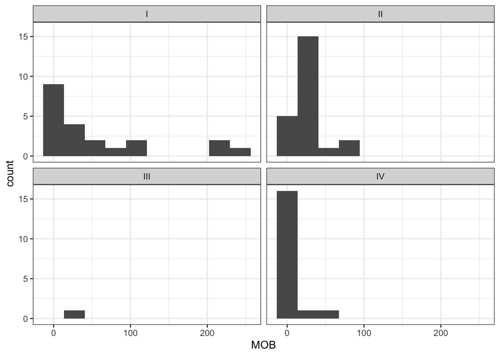

```r
ggplot(df_bats) +
  aes(x = MOB) +
  geom_histogram(bins = 10) +
  facet_wrap(~ Clade) +
  theme_bw()
```

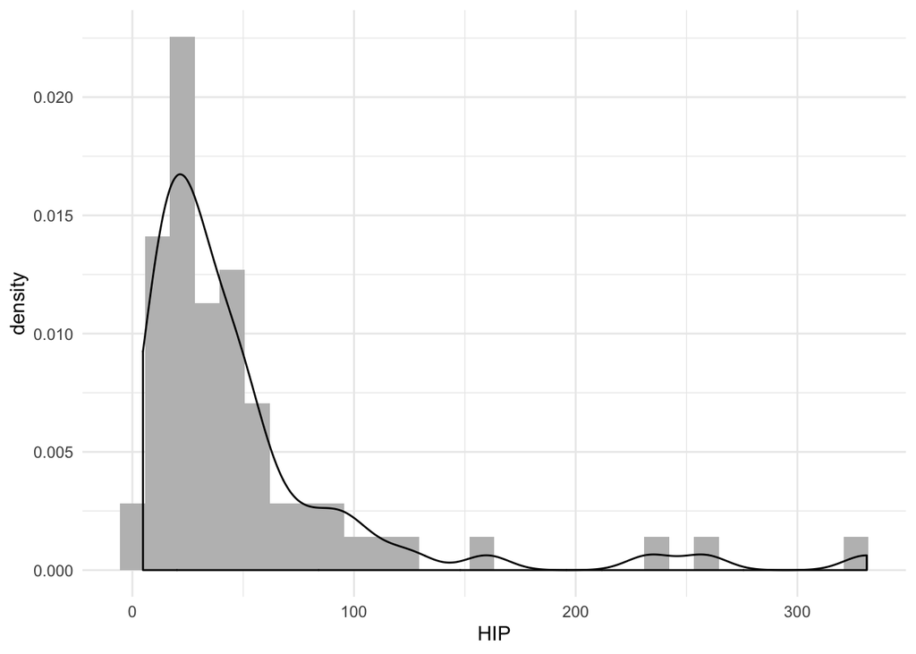

```r
ggplot(df_bats) +
  aes(x = HIP) +
  geom_histogram(aes(y = ..density..), fill = "grey") +
  geom_density(bins = 30)
```

# Analyse bivariée des données

#### 5

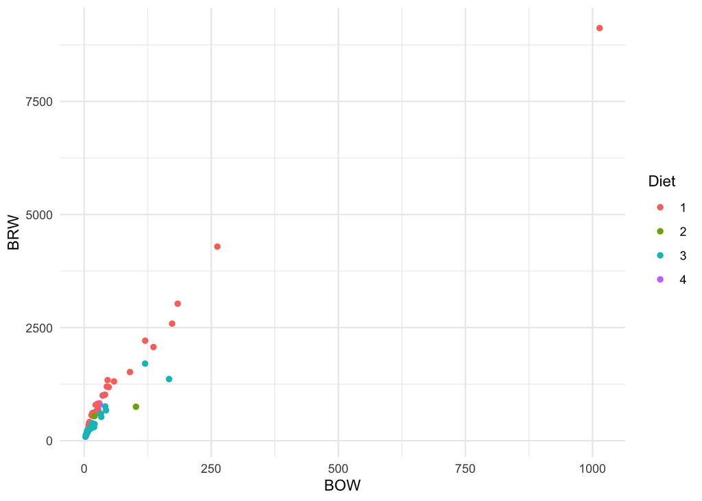

```r
ggplot(df_bats) +
  aes(x = BOW, y = BRW, color = Diet) +
  geom_point()
```

#### 6 & 7

Représenter une variable numérique par rapport à une variable catégorielle se fait principalement à l’aide de `geom_bowplot()`.

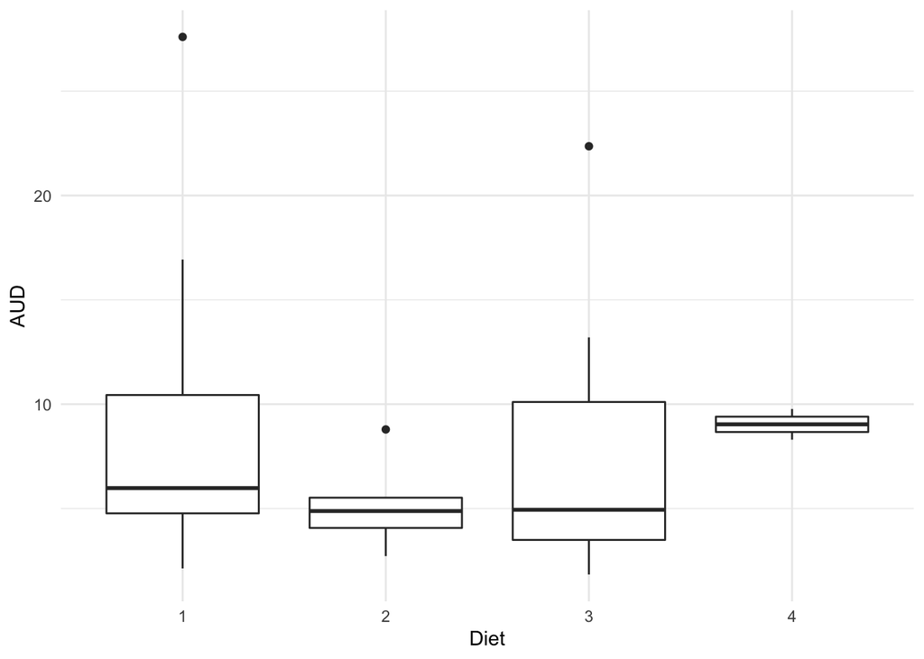

```r
ggplot(df_bats) +
  aes(x = Diet, y = AUD) +
  geom_boxplot()
```

Mais on peut aussi utiliser `geom_violin()` voir `geom_point()`.

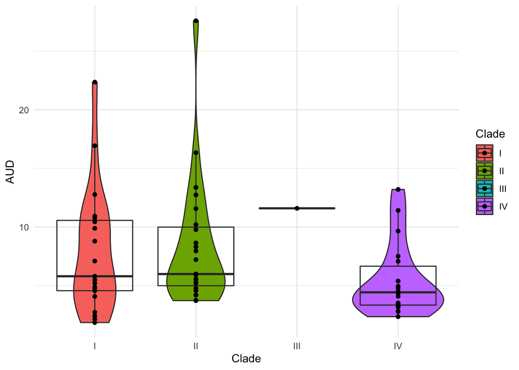

```r
ggplot(df_bats) +
  aes(x = Clade, y = AUD, fill = Clade) +
  geom_violin() +
  geom_boxplot(alpha = 0)  +
  geom_point()
```

# Analyse en composantes principales

#### 9

On ne sait calculer les corrélations qu’entre variables numériques, on ne va garder que celles-ci dans notre dataframe avant de les calculer.

```r
cor_bats <-
  df_bats %>%
  select_if(is.numeric) %>% # select_if() garde les colonnes qui respectent une condition
  cor()
cor_bats
```

```
##           BOW       BRW       AUD       MOB       HIP
## BOW 1.0000000 0.9618106 0.4660245 0.7685600 0.8170310
## BRW 0.9618106 1.0000000 0.5459500 0.8926875 0.9312282
## AUD 0.4660245 0.5459500 1.0000000 0.4104843 0.4553231
## MOB 0.7685600 0.8926875 0.4104843 1.0000000 0.9847818
## HIP 0.8170310 0.9312282 0.4553231 0.9847818 1.0000000
```

La fonction `corrplot()` du package **corrplot** permet de visualiser les corrélations et d’apprécier les relations entre variables bien plus facilement qu’avec la matrice.

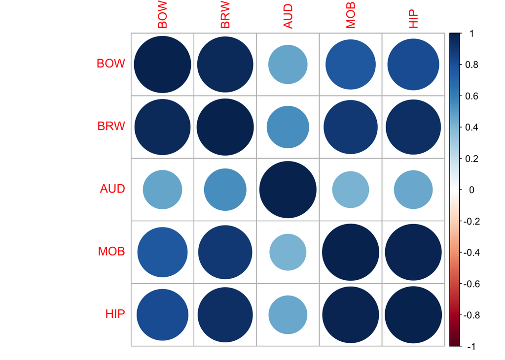

```r
corrplot::corrplot(cor_bats)
```

#### 10

On utilise la fonction `PCA()` en précisant quelles sont les variables qualitatives pour les exclure de l’analyse.

```r
res_pca <- PCA(df_bats, quali.sup = 1:3, quanti.sup = 4, graph = FALSE)
```

Valeurs propres.

```r
get_eigenvalue(res_pca)
```

```
##       eigenvalue variance.percent cumulative.variance.percent
## Dim.1 3.17776748       79.4441871                    79.44419
## Dim.2 0.71218810       17.8047026                    97.24889
## Dim.3 0.09989538        2.4973844                    99.74627
## Dim.4 0.01014903        0.2537259                   100.00000
```

Scree plot.

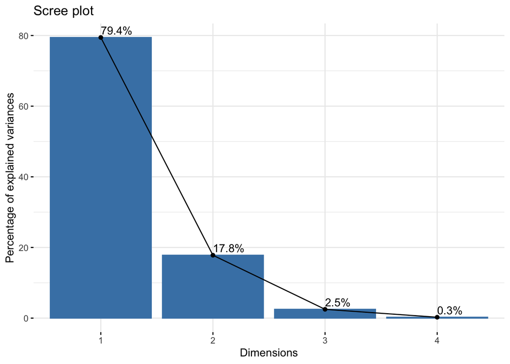

```r
fviz_eig(res_pca, addlabels = TRUE)
```

#### 11

`fviz_pca_var()` trace le cercle des corrélations.

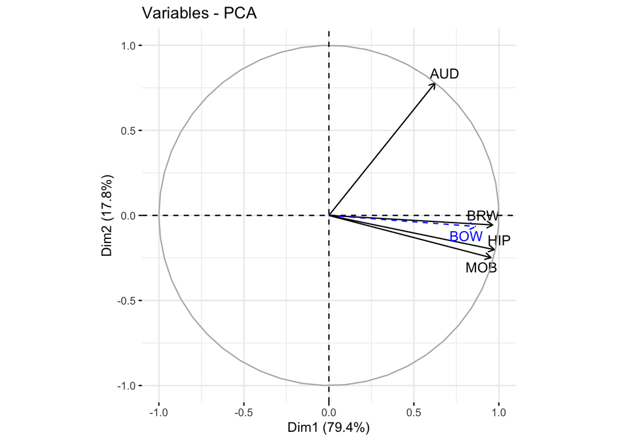

```r
fviz_pca_var(res_pca, repel = TRUE) # repel arrange les textes automatiquement
```

Comme prévu par le calcul des corrélations, `BOW`, `BRW`, `MOB` et `HIP` sont très corrélées.

#### 12

On peut choisir de colorier les individus par une variable catégorielle qu’on a préalablement spécifiée dans l’appel à `PCA()`.

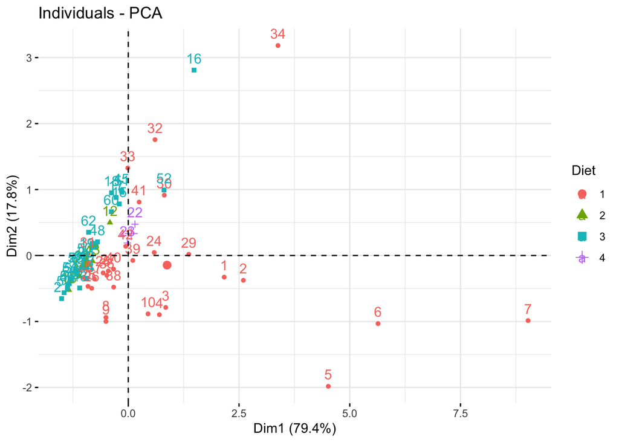

```r
fviz_pca_ind(res_pca, habillage = "Diet")
```

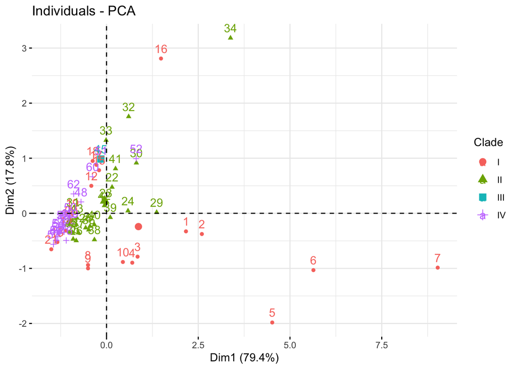

```r
fviz_pca_ind(res_pca, habillage = "Clade")
```

Ou on peut aussi les colorier par des statistiques associées aux individus, comme le cos carré.

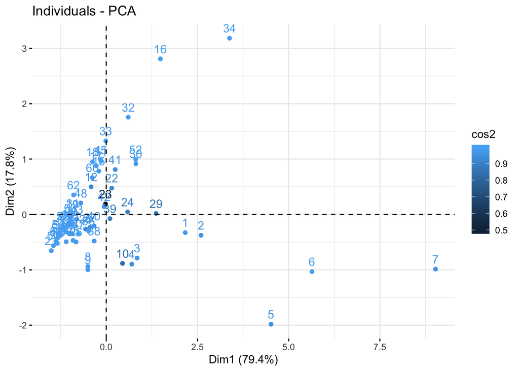

```r
fviz_pca_ind(res_pca, col.ind = "cos2")
```